# 02_intervals_sinusoidal

## 02_intervals_sinusoidal

#### Question

1. Let function $f$ be defined by the graph below.

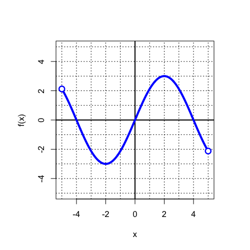

   - Over what interval is the function positive?
   - Over what interval is the function negative?
   - Over what interval is the function increasing?
   - Over what interval is the function decreasing?

#### Question

2. Let function $f$ be defined by the graph below.

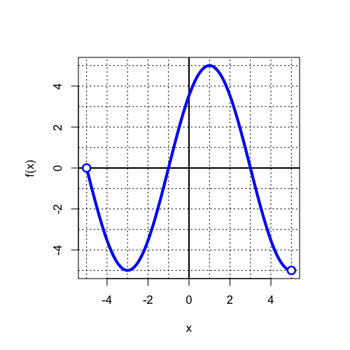

   - Over what interval is the function positive?
   - Over what interval is the function negative?
   - Over what interval is the function increasing?
   - Over what interval is the function decreasing?

#### Question

3. Let function $f$ be defined by the graph below.

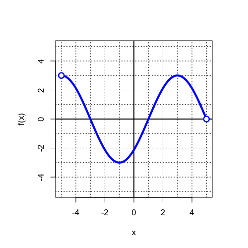

   - Over what interval is the function positive?
   - Over what interval is the function negative?
   - Over what interval is the function increasing?
   - Over what interval is the function decreasing?

#### Question

4. Let function $f$ be defined by the graph below.

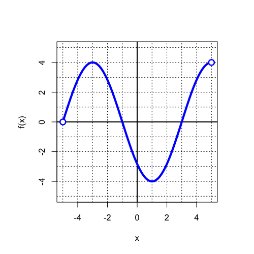

   - Over what interval is the function positive?
   - Over what interval is the function negative?
   - Over what interval is the function increasing?
   - Over what interval is the function decreasing?

#### Question

5. Let function $f$ be defined by the graph below.

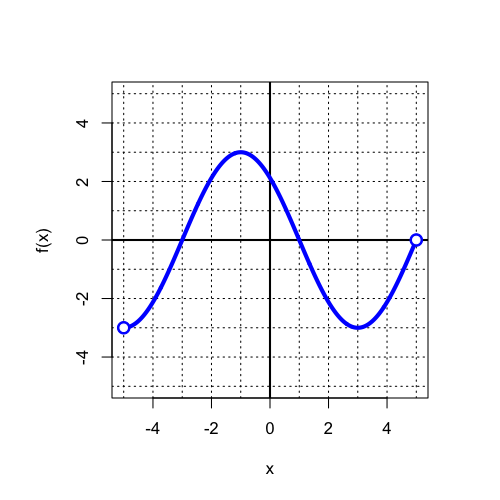

   - Over what interval is the function positive?
   - Over what interval is the function negative?
   - Over what interval is the function increasing?
   - Over what interval is the function decreasing?

#### Question

6. Let function $f$ be defined by the graph below.

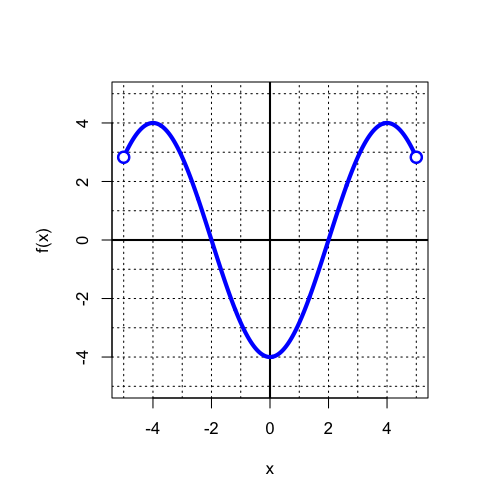

   - Over what interval is the function positive?
   - Over what interval is the function negative?
   - Over what interval is the function increasing?
   - Over what interval is the function decreasing?

#### Question

7. Let function $f$ be defined by the graph below.

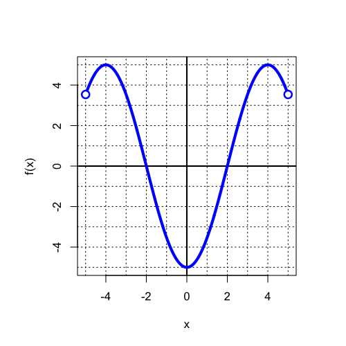

   - Over what interval is the function positive?
   - Over what interval is the function negative?
   - Over what interval is the function increasing?
   - Over what interval is the function decreasing?

#### Question

8. Let function $f$ be defined by the graph below.

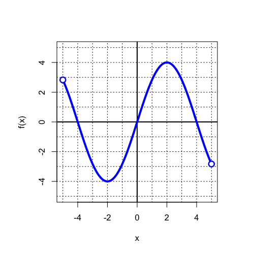

   - Over what interval is the function positive?
   - Over what interval is the function negative?
   - Over what interval is the function increasing?
   - Over what interval is the function decreasing?